# Food Web Analysis

Author

Lukas Meyer

ZHAW Institute for Natural Resource Sciences  
Module Applied Geoinformatics

## Summary

**KEYWORDS**: Food web, Network, Keystone species, Centrality index, Connectivity

# 1 Introduction

## 1.1 Food webs

Food webs are a form of ecological networks that represent the food chains of an ecosystem. These networks include no geographic relation, however the analysis of their structure and properties using python shows great similarity to analysing geographic networks. Though they do not include coordinates, the structure is essentially the same. Like spatial networks, food webs consist of nodes and edges. Likewise, connectivity, centrality, and shortest paths are all important aspects for their analysis. Each node represents a species, while the edges represent interactions between said species. The edges can either be weighted for the species interaction magnitude, or be of simple binary nature. These models are used to better understand ecosystems, to assess their quality, or in further modelling approaches to detect possible changes in ecosystem structure, due to factors such as an introduced species or environmental factors. In so called “removal analyses” the effect of removing certain species can be modelled (Hui, 2012; Pimm et al., 1991; Solé & Montoya, 2001) Ecopath is a modelling software based on mass-balance and a set of mathematical formulas, which can be used to construct a food web. It generates a snapshot of the ecosystem structure, which is a static model. Further studies of the ecosystem use Ecosim, which includes the temporal changes for the model, and Ecospace, which includes the spatial heterogeneity of the model (Christensen et al., 2005).

## 1.2 Indices

To describe networks a variety of indices can be calculated. Some indices describe the network in its entirety, and others inspect individual nodes. Centrality indices belong to the latter sort and play a big role in determining keystone species. These are the species that are most crucial for sustaining network stability. The search for the most accurate indices for assessing keystone species has been subject to a variety of studies in the past decades (Solé & Montoya, 2001), (Jordán et al., 2007). While a consensus has not been reached, methods to assess the stability of indices have been developed (Fedor & Vasas, 2009). The indices approach keystone-ness of a species in a network in different ways and show different aspects of their influence on the ecosystem. Following formulas for indices have been recalled from networkx documentation (Hagberg et al., 2008), and web of life documentation (Vindigni, 2022).

### 1.2.1 Degree centrality

Degree centrality index describes the number of connections a node has in relation to the total possible connections. A species with a high degree centrality acts as a local hub. This means that a large number of species are directly affected by its abundance. What the index doesn’t indicate is whether the node has a large impact on the entire network, since only immediate connections are considered (Rocchi et al., 2017). Further, it does not consider weighted edges and treats every edge in a binary manner. Degree centrality can be calculated as shown in (1). $d_v$ describes the degree of the node in question and $N$ describes the number of total nodes (Rocchi et al., 2017).

$$\begin{align}
c_d (v)= \frac{d_v}{N-1} \tag{1}\label{eq:1} \\
\end{align}$$

### 1.2.2 Betweenness centrality

Betweenness centrality index determines how often a node is included in the shortest paths between every node in the network. In a food web, nodes with high betweenness centrality indices act as transmitting paths to spread effects through the network (Rocchi et al., 2017). The calculation of betweenness centrality is defined as shown in (2).

$$\begin{align}
c_b (v)= \sum_{s,t,\epsilon V}^{} \frac{\sigma (s,t\mid v)}{\sigma (s,t)} \tag{2}\label{eq:2} \\
\end{align}$$

### 1.2.3 Closeness centrality

A nodes closeness centrality is biggest when its shortest paths to all other nodes are of minimal length. For food webs that means that the effect caused by the species abundance is spread most rapidly across the whole network (Rocchi et al., 2017). For the calculation, the improved formula from Wasserman and Faust has been used (Wasserman and Faust as cited in Hagberg et al., 2008). The formula is shown in (3). $n$ describes the number of reachable nodes from the node in question, $d(v,u)$ describes the shortest path between nodes $v$ and $u$.

$$\begin{align}
C_{WF}(v)=\frac{n-1}{N-1}\frac{n-1}{\sum_{v=1}^{n-1}d(v,u)} \tag{3}\label{eq:3} \\
\end{align}$$

### 1.2.4 In-degree

The in-degree is a measurement for directed networks. It assesses how many edges are pointed towards a particular node. In a food web, a high in-degree is characteristic for generalist predators that feed on many different species of prey (Rocchi et al., 2017).

### 1.2.5 Out-degree

Like the in-degree, the out-degree is used in directed networks. It measures how many edges are pointed away from the node in question. In a food web a high out-degree is characteristic for important prey species that serve as food source for many different predator species (Rocchi et al., 2017).

### 1.2.6 Trophic levels

$$\begin{align}
s(v)=1+\frac{1}{k_{v}^{in}}\sum_{j}^{}a_{vj}s_j \tag{4}\label{eq:4} \\
\end{align}$$

### 1.2.7 Connectivity

The connectivity index is a measure describing the entire network and not an individual node. A highly connected network is more stable and can therefore better withstand disturbance. For food webs, the connectivity can be calculated as shown in (5). $n_l$ describes the number of links and $N$ describes the number of nodes.

$$\begin{align}
C(G)=\frac{2n_l}{N(N-1)} \tag{5}\label{eq:5} \\
\end{align}$$

# 2 Methods

## 2.2 Setup

To examine the data, python (version 3.10.6) has been used in combination with the jupyter notebook environment (version 6.4.12). The python library networkx was used to create the network graph and calculate its indices. The python library bokeh was used for visualization.

## 2.3 Analysis

The data was available in the form of a weighted neighborhood matrix. To construct a graph with networkx, a list of nodes and a list of edges had to be provided. Those were extracted from the matrix by accessing the respective columns and using a for loop. First an empty graph model in the form of a “MultiDiGraph” (directed graph with self loops and parallel edges) was created. Self loops had to be allowed because in some cases, species may feed on its own kind. Parallel edges can also be possible in food webs, because two species may feed on each other. Then, the nodes and edges were added, also providing the weight of the edges in the same step. For calculating indices, networkx provided all the functions required. The indices were saved in variables and later accessed when visualising. Bokeh does not accept graphs unless the node names are given as integer types. Therefore, the species names were changed to numbers.

# 3 Results

## 3.1 Import Data

At first the weighted neighborhood matrix (Table 1) has been imported.

```python
import pandas as pd
foodweb = pd.read_csv("FW_016_01.csv")
foodweb
```

Table 1: weighted neighborhood matrix

|  | Unnamed: 0 | Alkmaria romijni | Ampithoe valida | Aonides oxycephala | Capitella capitata | Carcinus maenas | Cerastoderma edule | Chaetozone setosa | Crangon crangon | Cyathura carinata | ... | Lumbrineris impatiens | Melita palmata | Mytilus sp1 FW_016_01 | Nemertini | Nephthys sp1 FW_016_01 | Oligochaeta | Pygospio elegans | Scrobicularia plana | Streblospio shrubsolii | Zooplankton |
| --- | --- | --- | --- | --- | --- | --- | --- | --- | --- | --- | --- | --- | --- | --- | --- | --- | --- | --- | --- | --- | --- |
| 0 | Alkmaria romijni | 0.0 | 0.0 | 0 | 0 | 0.000 | 0.0 | 0 | 0.003 | 0.020 | ... | 0.000 | 0.0 | 0.0 | 0.000 | 0.001 | 0 | 0.0 | 0.0 | 0 | 0.00 |
| 1 | Ampithoe valida | 0.0 | 0.0 | 0 | 0 | 0.040 | 0.0 | 0 | 0.037 | 0.050 | ... | 0.001 | 0.0 | 0.0 | 0.050 | 0.006 | 0 | 0.0 | 0.0 | 0 | 0.00 |
| 2 | Aonides oxycephala | 0.0 | 0.0 | 0 | 0 | 0.001 | 0.0 | 0 | 0.001 | 0.001 | ... | 0.001 | 0.0 | 0.0 | 0.005 | 0.001 | 0 | 0.0 | 0.0 | 0 | 0.00 |
| 3 | Capitella capitata | 0.0 | 0.0 | 0 | 0 | 0.000 | 0.0 | 0 | 0.000 | 0.004 | ... | 0.002 | 0.0 | 0.0 | 0.000 | 0.012 | 0 | 0.0 | 0.0 | 0 | 0.00 |
| 4 | Carcinus maenas | 0.0 | 0.0 | 0 | 0 | 0.060 | 0.0 | 0 | 0.010 | 0.055 | ... | 0.000 | 0.0 | 0.0 | 0.000 | 0.000 | 0 | 0.0 | 0.0 | 0 | 0.00 |
| 5 | Cerastoderma edule | 0.0 | 0.0 | 0 | 0 | 0.020 | 0.0 | 0 | 0.030 | 0.000 | ... | 0.034 | 0.0 | 0.0 | 0.040 | 0.050 | 0 | 0.0 | 0.0 | 0 | 0.00 |
| 6 | Chaetozone setosa | 0.0 | 0.0 | 0 | 0 | 0.018 | 0.0 | 0 | 0.013 | 0.000 | ... | 0.001 | 0.0 | 0.0 | 0.030 | 0.010 | 0 | 0.0 | 0.0 | 0 | 0.00 |
| 7 | Crangon crangon | 0.0 | 0.0 | 0 | 0 | 0.140 | 0.0 | 0 | 0.010 | 0.000 | ... | 0.000 | 0.0 | 0.0 | 0.000 | 0.000 | 0 | 0.0 | 0.0 | 0 | 0.00 |
| 8 | Cyathura carinata | 0.0 | 0.0 | 0 | 0 | 0.030 | 0.0 | 0 | 0.040 | 0.000 | ... | 0.010 | 0.0 | 0.0 | 0.030 | 0.000 | 0 | 0.0 | 0.0 | 0 | 0.00 |
| 9 | Detritus | 0.9 | 0.7 | 1 | 1 | 0.150 | 0.1 | 1 | 0.300 | 0.700 | ... | 0.600 | 0.7 | 0.1 | 0.200 | 0.550 | 1 | 0.4 | 0.6 | 1 | 0.00 |
| 10 | Diopatra neapolitana | 0.0 | 0.0 | 0 | 0 | 0.001 | 0.0 | 0 | 0.001 | 0.000 | ... | 0.000 | 0.0 | 0.0 | 0.005 | 0.001 | 0 | 0.0 | 0.0 | 0 | 0.00 |
| 11 | Eteone flava | 0.0 | 0.0 | 0 | 0 | 0.000 | 0.0 | 0 | 0.001 | 0.000 | ... | 0.000 | 0.0 | 0.0 | 0.001 | 0.000 | 0 | 0.0 | 0.0 | 0 | 0.00 |
| 12 | Gibulla umbilicalis | 0.0 | 0.0 | 0 | 0 | 0.001 | 0.0 | 0 | 0.001 | 0.000 | ... | 0.020 | 0.0 | 0.0 | 0.005 | 0.000 | 0 | 0.0 | 0.0 | 0 | 0.00 |
| 13 | Glycera tridactyla | 0.0 | 0.0 | 0 | 0 | 0.020 | 0.0 | 0 | 0.010 | 0.009 | ... | 0.002 | 0.0 | 0.0 | 0.040 | 0.024 | 0 | 0.0 | 0.0 | 0 | 0.00 |
| 14 | Green macroalgae | 0.0 | 0.2 | 0 | 0 | 0.040 | 0.0 | 0 | 0.050 | 0.000 | ... | 0.000 | 0.2 | 0.0 | 0.000 | 0.000 | 0 | 0.0 | 0.0 | 0 | 0.00 |
| 15 | Haminoea hydatis | 0.0 | 0.0 | 0 | 0 | 0.001 | 0.0 | 0 | 0.000 | 0.000 | ... | 0.014 | 0.0 | 0.0 | 0.005 | 0.000 | 0 | 0.0 | 0.0 | 0 | 0.00 |
| 16 | Hediste diversicolor | 0.0 | 0.0 | 0 | 0 | 0.080 | 0.0 | 0 | 0.090 | 0.050 | ... | 0.004 | 0.0 | 0.0 | 0.230 | 0.080 | 0 | 0.0 | 0.0 | 0 | 0.00 |
| 17 | Heteromastus filiformis | 0.0 | 0.0 | 0 | 0 | 0.005 | 0.0 | 0 | 0.040 | 0.030 | ... | 0.005 | 0.0 | 0.0 | 0.077 | 0.100 | 0 | 0.0 | 0.0 | 0 | 0.00 |
| 18 | Hydrobia ulvae | 0.0 | 0.0 | 0 | 0 | 0.030 | 0.0 | 0 | 0.070 | 0.000 | ... | 0.070 | 0.0 | 0.0 | 0.050 | 0.000 | 0 | 0.0 | 0.0 | 0 | 0.00 |
| 19 | Idotea chelipes | 0.0 | 0.0 | 0 | 0 | 0.005 | 0.0 | 0 | 0.005 | 0.010 | ... | 0.001 | 0.0 | 0.0 | 0.010 | 0.000 | 0 | 0.0 | 0.0 | 0 | 0.00 |
| 20 | Imports | 0.0 | 0.0 | 0 | 0 | 0.180 | 0.0 | 0 | 0.060 | 0.000 | ... | 0.000 | 0.0 | 0.0 | 0.000 | 0.000 | 0 | 0.0 | 0.0 | 0 | 0.00 |
| 21 | Lagis koreni | 0.0 | 0.0 | 0 | 0 | 0.001 | 0.0 | 0 | 0.002 | 0.000 | ... | 0.000 | 0.0 | 0.0 | 0.005 | 0.000 | 0 | 0.0 | 0.0 | 0 | 0.00 |
| 22 | Lekanesphaera levii | 0.0 | 0.0 | 0 | 0 | 0.000 | 0.0 | 0 | 0.000 | 0.001 | ... | 0.000 | 0.0 | 0.0 | 0.001 | 0.000 | 0 | 0.0 | 0.0 | 0 | 0.00 |
| 23 | Littorina littorea | 0.0 | 0.0 | 0 | 0 | 0.010 | 0.0 | 0 | 0.010 | 0.000 | ... | 0.035 | 0.0 | 0.0 | 0.010 | 0.000 | 0 | 0.0 | 0.0 | 0 | 0.00 |
| 24 | Lumbrineris impatiens | 0.0 | 0.0 | 0 | 0 | 0.010 | 0.0 | 0 | 0.015 | 0.000 | ... | 0.000 | 0.0 | 0.0 | 0.020 | 0.002 | 0 | 0.0 | 0.0 | 0 | 0.00 |
| 25 | Melita palmata | 0.0 | 0.0 | 0 | 0 | 0.030 | 0.0 | 0 | 0.030 | 0.045 | ... | 0.002 | 0.0 | 0.0 | 0.040 | 0.008 | 0 | 0.0 | 0.0 | 0 | 0.00 |
| 26 | Microphytobenthos | 0.0 | 0.1 | 0 | 0 | 0.000 | 0.1 | 0 | 0.000 | 0.000 | ... | 0.050 | 0.1 | 0.1 | 0.000 | 0.050 | 0 | 0.0 | 0.2 | 0 | 0.00 |
| 27 | Mytilus sp1 FW_016_01 | 0.0 | 0.0 | 0 | 0 | 0.001 | 0.0 | 0 | 0.005 | 0.000 | ... | 0.000 | 0.0 | 0.0 | 0.000 | 0.000 | 0 | 0.0 | 0.0 | 0 | 0.00 |
| 28 | Nemertini | 0.0 | 0.0 | 0 | 0 | 0.000 | 0.0 | 0 | 0.000 | 0.000 | ... | 0.001 | 0.0 | 0.0 | 0.050 | 0.000 | 0 | 0.0 | 0.0 | 0 | 0.00 |
| 29 | Nephthys sp1 FW_016_01 | 0.0 | 0.0 | 0 | 0 | 0.005 | 0.0 | 0 | 0.001 | 0.000 | ... | 0.001 | 0.0 | 0.0 | 0.005 | 0.001 | 0 | 0.0 | 0.0 | 0 | 0.00 |
| 30 | Oligochaeta | 0.0 | 0.0 | 0 | 0 | 0.001 | 0.0 | 0 | 0.005 | 0.020 | ... | 0.010 | 0.0 | 0.0 | 0.050 | 0.080 | 0 | 0.0 | 0.0 | 0 | 0.00 |
| 31 | Phytoplankton | 0.1 | 0.0 | 0 | 0 | 0.000 | 0.8 | 0 | 0.000 | 0.000 | ... | 0.000 | 0.0 | 0.8 | 0.000 | 0.000 | 0 | 0.6 | 0.2 | 0 | 0.98 |
| 32 | Pygospio elegans | 0.0 | 0.0 | 0 | 0 | 0.000 | 0.0 | 0 | 0.000 | 0.000 | ... | 0.000 | 0.0 | 0.0 | 0.001 | 0.000 | 0 | 0.0 | 0.0 | 0 | 0.00 |
| 33 | Scrobicularia plana | 0.0 | 0.0 | 0 | 0 | 0.060 | 0.0 | 0 | 0.060 | 0.000 | ... | 0.035 | 0.0 | 0.0 | 0.030 | 0.024 | 0 | 0.0 | 0.0 | 0 | 0.00 |
| 34 | Streblospio shrubsolii | 0.0 | 0.0 | 0 | 0 | 0.000 | 0.0 | 0 | 0.000 | 0.005 | ... | 0.001 | 0.0 | 0.0 | 0.005 | 0.000 | 0 | 0.0 | 0.0 | 0 | 0.00 |
| 35 | Zooplankton | 0.0 | 0.0 | 0 | 0 | 0.060 | 0.0 | 0 | 0.100 | 0.000 | ... | 0.000 | 0.0 | 0.0 | 0.005 | 0.000 | 0 | 0.0 | 0.0 | 0 | 0.02 |
| 36 | Zostera noltii | 0.0 | 0.0 | 0 | 0 | 0.000 | 0.0 | 0 | 0.000 | 0.000 | ... | 0.100 | 0.0 | 0.0 | 0.000 | 0.000 | 0 | 0.0 | 0.0 | 0 | 0.00 |

37 rows × 32 columns

## 3.2 Node list

```python
nodes_wduplicates = list(foodweb.iloc[:,0]) + list(foodweb.iloc[:, 1:-3].columns)
nodes = list(dict.fromkeys(nodes_wduplicates))
```

## 3.3 Edge list

For every edge in the network the connected nodes and weight of the link had to be extracted to (Table 2).

```python
u = list(range(0,len(foodweb)))
v = list(range(1,len(foodweb.columns)-3))

column_link = []
row_link = []
strength_link = []

for i in u:
    for j in v:
        strength_val = foodweb.iloc[i,j]
        if strength_val > 0:
            column_link.append(j)
            row_link.append(i)
            strength_link.append(strength_val)

column_link_names = list(foodweb.columns[column_link])
row_link_names = list(foodweb.iloc[row_link,0])

links = pd.DataFrame(list(zip(row_link_names,column_link_names,strength_link)))
links
```

Table 2: edge list with weight

|  | 0 | 1 | 2 |
| --- | --- | --- | --- |
| 0 | Alkmaria romijni | Crangon crangon | 0.003 |
| 1 | Alkmaria romijni | Cyathura carinata | 0.020 |
| 2 | Alkmaria romijni | Glycera tridactyla | 0.010 |
| 3 | Alkmaria romijni | Nephthys sp1 FW_016_01 | 0.001 |
| 4 | Ampithoe valida | Carcinus maenas | 0.040 |
| ... | ... | ... | ... |
| 231 | Zooplankton | Crangon crangon | 0.100 |
| 232 | Zooplankton | Nemertini | 0.005 |
| 233 | Zostera noltii | Idotea chelipes | 0.050 |
| 234 | Zostera noltii | Littorina littorea | 0.200 |
| 235 | Zostera noltii | Lumbrineris impatiens | 0.100 |

236 rows × 3 columns

## 3.4 Network graph

The graph has been constructed using networkx. In (Figure 1) a first visualisation of the network can be seen.

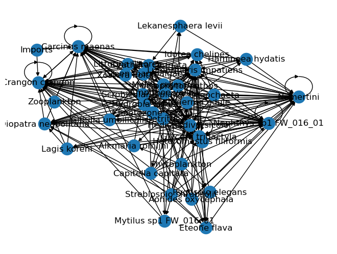

```python
import networkx as nx

G = nx.MultiDiGraph()

for node in nodes:
    G.add_node(node, name = node)

for link in list(links.index):
    G.add_edge(links.iloc[link,0], links.iloc[link,1], weight = links.iloc[link,2])

nx.draw(G, with_labels = True)
```

Figure 1: networkx graph

## 3.5 Converting to integer node names

```python
Gint = nx.convert_node_labels_to_integers(G, ordering="default")
```

## 3.6 Calculating indices

The indices have been calculated using networkx and summarised in (Table 3).

```python
# degree centrality
degree = nx.degree_centrality(Gint)
degree_list = list(degree.values())
indegree = nx.in_degree_centrality(Gint)
indegree_list = list(indegree.values())
outdegree = nx.out_degree_centrality(Gint)
outdegree_list = list(outdegree.values())

# closeness centrality
closeness = nx.closeness_centrality(Gint,distance='weight',wf_improved=True)
closeness_list = list(closeness.values())

# betweenness centrality
betweenness = nx.betweenness_centrality(Gint, weight='weight')
betweenness_list = list(betweenness.values())

#trophic levels
trophic = nx.trophic_levels(Gint,weight='weight')

indices = pd.DataFrame({'dc':pd.Series(degree), 'cc':pd.Series(closeness), 'bc':pd.Series(betweenness), 'in-degree':pd.Series(indegree), 'out-degree':pd.Series(outdegree), 'trophic':pd.Series(trophic)})
indices
```

Table 3: indices for nodes

|  | dc | cc | bc | in-degree | out-degree | trophic |
| --- | --- | --- | --- | --- | --- | --- |
| 0 | 0.166667 | 0.111111 | 0.000000 | 0.055556 | 0.111111 | 2.000000 |
| 1 | 0.333333 | 0.250000 | 0.000661 | 0.083333 | 0.250000 | 2.000000 |
| 2 | 0.277778 | 0.027778 | 0.000000 | 0.027778 | 0.250000 | 2.000000 |
| 3 | 0.166667 | 0.027778 | 0.000000 | 0.027778 | 0.138889 | 2.000000 |
| 4 | 0.833333 | 42.056075 | 0.017857 | 0.750000 | 0.083333 | 2.677543 |
| 5 | 0.305556 | 0.250000 | 0.001852 | 0.083333 | 0.222222 | 2.000000 |
| 6 | 0.250000 | 0.027778 | 0.000000 | 0.027778 | 0.222222 | 2.000000 |
| 7 | 0.833333 | 63.380282 | 0.000000 | 0.777778 | 0.055556 | 2.498839 |
| 8 | 0.500000 | 27.777778 | 0.019048 | 0.388889 | 0.111111 | 2.357648 |
| 9 | 0.777778 | 0.000000 | 0.000000 | 0.000000 | 0.777778 | 1.000000 |
| 10 | 0.416667 | 3.260031 | 0.011905 | 0.277778 | 0.138889 | 2.180000 |
| 11 | 0.277778 | 12.491325 | 0.005556 | 0.194444 | 0.083333 | 2.784911 |
| 12 | 0.194444 | 0.250000 | 0.002778 | 0.083333 | 0.111111 | 2.000000 |
| 13 | 0.888889 | 31.746032 | 0.047619 | 0.638889 | 0.250000 | 2.707078 |
| 14 | 0.222222 | 0.000000 | 0.000000 | 0.000000 | 0.222222 | 1.000000 |
| 15 | 0.166667 | 0.250000 | 0.002778 | 0.083333 | 0.083333 | 2.000000 |
| 16 | 0.722222 | 32.967033 | 0.007143 | 0.500000 | 0.222222 | 2.330379 |
| 17 | 0.305556 | 0.027778 | 0.000000 | 0.027778 | 0.277778 | 2.000000 |
| 18 | 0.250000 | 0.111111 | 0.000000 | 0.055556 | 0.194444 | 2.000000 |
| 19 | 0.333333 | 1.000000 | 0.007143 | 0.166667 | 0.166667 | 2.250000 |
| 20 | 0.055556 | 0.000000 | 0.000000 | 0.000000 | 0.055556 | 1.000000 |
| 21 | 0.194444 | 0.027778 | 0.000000 | 0.027778 | 0.166667 | 2.000000 |
| 22 | 0.111111 | 0.111111 | 0.000000 | 0.055556 | 0.055556 | 2.000000 |
| 23 | 0.250000 | 0.444444 | 0.000000 | 0.111111 | 0.138889 | 2.000000 |
| 24 | 0.777778 | 34.220532 | 0.096429 | 0.638889 | 0.138889 | 2.221915 |
| 25 | 0.333333 | 0.250000 | 0.000661 | 0.083333 | 0.250000 | 2.000000 |
| 26 | 0.361111 | 0.000000 | 0.000000 | 0.000000 | 0.361111 | 1.000000 |
| 27 | 0.138889 | 0.250000 | 0.000794 | 0.083333 | 0.055556 | 2.000000 |
| 28 | 0.861111 | 30.176027 | 0.045238 | 0.750000 | 0.111111 | 2.932342 |
| 29 | 0.666667 | 32.490975 | 0.094841 | 0.472222 | 0.194444 | 2.420444 |
| 30 | 0.277778 | 0.027778 | 0.000000 | 0.027778 | 0.250000 | 2.000000 |
| 31 | 0.138889 | 0.000000 | 0.000000 | 0.000000 | 0.138889 | 1.000000 |
| 32 | 0.138889 | 0.111111 | 0.000000 | 0.055556 | 0.083333 | 2.000000 |
| 33 | 0.222222 | 0.000000 | 0.000000 | 0.000000 | 0.222222 | 1.000000 |
| 34 | 0.194444 | 0.000000 | 0.000000 | 0.000000 | 0.194444 | 1.000000 |
| 35 | 0.083333 | 0.000000 | 0.000000 | 0.000000 | 0.083333 | 1.000000 |
| 36 | 0.083333 | 0.000000 | 0.000000 | 0.000000 | 0.083333 | 1.000000 |

## 3.7 Ranking

The species have been ranked for every index calculated as it can be seen in (Table 4).

```python
keystone_rank = pd.DataFrame()
keystone_rank['dc_rank'] = indices['dc'].rank(ascending=False)
keystone_rank['cc_rank'] = indices['cc'].rank(ascending=False)
keystone_rank['bc_rank'] = indices['bc'].rank(ascending=False)
keystone_rank['indegree_rank'] = indices['in-degree'].rank(ascending=False)
keystone_rank['outdegree_rank'] = indices['out-degree'].rank(ascending=False)
keystone_rank['trophic_rank'] = indices['trophic'].rank(ascending=False)
keystone_rank
```

Table 4: nodes ranked by indices

|  | dc_rank | cc_rank | bc_rank | indegree_rank | outdegree_rank | trophic_rank |
| --- | --- | --- | --- | --- | --- | --- |
| 0 | 29.0 | 20.5 | 27.0 | 20.5 | 25.5 | 20.0 |
| 1 | 13.0 | 15.5 | 15.5 | 15.5 | 6.0 | 20.0 |
| 2 | 18.0 | 25.5 | 27.0 | 25.5 | 6.0 | 20.0 |
| 3 | 29.0 | 25.5 | 27.0 | 25.5 | 21.0 | 20.0 |
| 4 | 3.5 | 2.0 | 6.0 | 2.5 | 30.5 | 4.0 |
| 5 | 15.5 | 15.5 | 13.0 | 15.5 | 11.0 | 20.0 |
| 6 | 21.0 | 25.5 | 27.0 | 25.5 | 11.0 | 20.0 |
| 7 | 3.5 | 1.0 | 27.0 | 1.0 | 35.5 | 5.0 |
| 8 | 9.0 | 8.0 | 5.0 | 8.0 | 25.5 | 7.0 |
| 9 | 5.5 | 33.0 | 27.0 | 33.0 | 1.0 | 33.0 |
| 10 | 10.0 | 10.0 | 7.0 | 9.0 | 21.0 | 11.0 |
| 11 | 18.0 | 9.0 | 10.0 | 10.0 | 30.5 | 2.0 |
| 12 | 26.0 | 15.5 | 11.5 | 15.5 | 25.5 | 20.0 |
| 13 | 1.0 | 6.0 | 3.0 | 4.5 | 6.0 | 3.0 |
| 14 | 23.5 | 33.0 | 27.0 | 33.0 | 11.0 | 33.0 |
| 15 | 29.0 | 15.5 | 11.5 | 15.5 | 30.5 | 20.0 |
| 16 | 7.0 | 4.0 | 8.5 | 6.0 | 11.0 | 8.0 |
| 17 | 15.5 | 25.5 | 27.0 | 25.5 | 3.0 | 20.0 |
| 18 | 21.0 | 20.5 | 27.0 | 20.5 | 15.0 | 20.0 |
| 19 | 13.0 | 11.0 | 8.5 | 11.0 | 17.5 | 9.0 |
| 20 | 37.0 | 33.0 | 27.0 | 33.0 | 35.5 | 33.0 |
| 21 | 26.0 | 25.5 | 27.0 | 25.5 | 17.5 | 20.0 |
| 22 | 34.0 | 20.5 | 27.0 | 20.5 | 35.5 | 20.0 |
| 23 | 21.0 | 12.0 | 27.0 | 12.0 | 21.0 | 20.0 |
| 24 | 5.5 | 3.0 | 1.0 | 4.5 | 21.0 | 10.0 |
| 25 | 13.0 | 15.5 | 15.5 | 15.5 | 6.0 | 20.0 |
| 26 | 11.0 | 33.0 | 27.0 | 33.0 | 2.0 | 33.0 |
| 27 | 32.0 | 15.5 | 14.0 | 15.5 | 35.5 | 20.0 |
| 28 | 2.0 | 7.0 | 4.0 | 2.5 | 25.5 | 1.0 |
| 29 | 8.0 | 5.0 | 2.0 | 7.0 | 15.0 | 6.0 |
| 30 | 18.0 | 25.5 | 27.0 | 25.5 | 6.0 | 20.0 |
| 31 | 32.0 | 33.0 | 27.0 | 33.0 | 21.0 | 33.0 |
| 32 | 32.0 | 20.5 | 27.0 | 20.5 | 30.5 | 20.0 |
| 33 | 23.5 | 33.0 | 27.0 | 33.0 | 11.0 | 33.0 |
| 34 | 26.0 | 33.0 | 27.0 | 33.0 | 15.0 | 33.0 |
| 35 | 35.5 | 33.0 | 27.0 | 33.0 | 30.5 | 33.0 |
| 36 | 35.5 | 33.0 | 27.0 | 33.0 | 30.5 | 33.0 |

## 3.8 Connectivity

```python
connectivity = (2* len(Gint.edges())) / (len(nodes) * (len(nodes)-1))
connectivity
```

```
0.35435435435435436
```

## 3.9 Visualising graph

```python
from bokeh.models import Circle, MultiLine, StaticLayoutProvider
from bokeh.plotting import figure, from_networkx, show
from bokeh.io import output_notebook
from bokeh.transform import linear_cmap
from bokeh.palettes import Plasma8

p = figure(width=650, height=650, x_range=(-3, 3), y_range=(-3, 3),
           tools="hover,wheel_zoom,pan,reset", toolbar_location='above',
           x_axis_location=None, y_axis_location=None,
           title=None)

p.grid.grid_line_color = None

graph = from_networkx(Gint, nx.spring_layout, scale=2, center=(0,0))

graph.node_renderer.data_source.add([i for i in degree_list], 'degree')
graph.node_renderer.data_source.add([i*25+5 for i in degree_list], 'size')
graph.node_renderer.data_source.add([i for i in closeness_list], 'closeness')
graph.node_renderer.data_source.add([i for i in betweenness_list], 'betweenness')
graph.node_renderer.data_source.add([i for i in indegree_list], 'indegree')
graph.node_renderer.data_source.add([i for i in outdegree_list], 'outdegree')
graph.node_renderer.data_source.add([i for i in nodes], 'name')
graph.edge_renderer.data_source.add([i*3+1 for i in strength_link], 'weight')

graph.node_renderer.glyph = Circle(
    size='size',
    fill_color=linear_cmap('degree', 'Plasma8', low=0, high=1))

graph.edge_renderer.glyph = MultiLine(line_width = 'weight')

p.hover.tooltips = [("index","@index"), ("name","@name"), ("degree","@degree"), ("closeness","@closeness"), ("betweenness","@betweenness"),
                    ("indegree","@indegree"), ("outdegree", "@outdegree")]

p.renderers.append(graph)

output_notebook()
show(p)
```

Loading BokehJS ...

```python
p = figure(width=650, height=650, x_range=(-3, 3), y_range=(-3, 3),
           tools="hover,wheel_zoom,pan,reset", toolbar_location='above',
           x_axis_location=None, y_axis_location=None,
           title=None)

p.grid.grid_line_color = None

graph = from_networkx(Gint, nx.spring_layout, scale=2, center=(0,0))

graph.node_renderer.data_source.add([i for i in degree_list], 'degree')
graph.node_renderer.data_source.add([i/4+10 for i in closeness_list], 'size')
graph.node_renderer.data_source.add([i for i in closeness_list], 'closeness')
graph.node_renderer.data_source.add([i for i in betweenness_list], 'betweenness')
graph.node_renderer.data_source.add([i for i in indegree_list], 'indegree')
graph.node_renderer.data_source.add([i for i in outdegree_list], 'outdegree')
graph.node_renderer.data_source.add([i for i in nodes], 'name')
graph.edge_renderer.data_source.add([i*3+1 for i in strength_link], 'weight')

graph.node_renderer.glyph = Circle(
    size='size',
    fill_color=linear_cmap('closeness', 'Plasma8', low=0, high=1))

graph.edge_renderer.glyph = MultiLine(line_width = 'weight')

p.hover.tooltips = [("index","@index"), ("name","@name"), ("degree","@degree"), ("closeness","@closeness"), ("betweenness","@betweenness"),
                    ("indegree","@indegree"), ("outdegree", "@outdegree")]

p.renderers.append(graph)

output_notebook()
show(p)
```

Loading BokehJS ...

```python
p = figure(width=650, height=650, x_range=(-3, 3), y_range=(-3, 3),
           tools="hover,wheel_zoom,pan,reset", toolbar_location='above',
           x_axis_location=None, y_axis_location=None,
           title=None)

p.grid.grid_line_color = None

graph = from_networkx(Gint, nx.spring_layout, scale=2, center=(0,0))

graph.node_renderer.data_source.add([i for i in degree_list], 'degree')
graph.node_renderer.data_source.add([i*200+10 for i in betweenness_list], 'size')
graph.node_renderer.data_source.add([i for i in closeness_list], 'closeness')
graph.node_renderer.data_source.add([i for i in betweenness_list], 'betweenness')
graph.node_renderer.data_source.add([i for i in indegree_list], 'indegree')
graph.node_renderer.data_source.add([i for i in outdegree_list], 'outdegree')
graph.node_renderer.data_source.add([i for i in nodes], 'name')
graph.edge_renderer.data_source.add([i*3+1 for i in strength_link], 'weight')

graph.node_renderer.glyph = Circle(
    size='size',
    fill_color=linear_cmap('betweenness', 'Plasma8', low=0, high=0.1))

graph.edge_renderer.glyph = MultiLine(line_width = 'weight')

p.hover.tooltips = [("index","@index"), ("name","@name"), ("degree","@degree"), ("closeness","@closeness"), ("betweenness","@betweenness"),
                    ("indegree","@indegree"), ("outdegree", "@outdegree")]

p.renderers.append(graph)

output_notebook()
show(p)
```

Loading BokehJS ...

# 4 Discussion

Another interesting index to calculate would have been the keystone index. It uses both a top-down and bottom-up approach for calculating the species importance (Jordán as cited in Fedor & Vasas, 2009; Gouveia et al., 2021). The omnivory index would have posed another interesting index. Like connectivity, it is a measure given for an entire network and rates its stability. Having omnivorous species in a network is important because it makes it possible for the predators to substitute for one another when one species is declining or extinct (Libralato, 2008).

An alternative to using networkx would have been the igraph package. Networkx was chosen as tool for analysis because it provides straight forward functions for different centrality indices. While it is also possible to calculate these indices using igraph, it requires a bit more knowledge of the library functions. However, for certain indices like the omnivory index or the keystone index, there are no functions in networkx either. For more thorough studies, the indices would have to be calculated using mathematical formulas directly either way. An advantage of igraph is that it is compatible with R and C (Igraph Documentation, 2023). For visualising, bokeh has been very useful, however there is no way to depict directed edges using this library. Alternatives would have been using networkx or igraph which would have only been able to produce non interactive plots with very little visual customization options. Pyvis or gravis would have presented interesting approaches, but pyvis has shown errors displaying the graph correctly in jupyter notebook and gravis had limited options. Plotly was the most promising library apart from bokeh, with even more options to choose from. Bokeh was ultimately chosen for being less complex and easier to handle. A problem with using bokeh with networkx was that the locations for the nodes were different every time a graph was generated. Thus, a comparison of the indices is harder to visualise effectively. This happened because no fixed x- and y-coordinates were assigned to the nodes, but the layout was loaded from networkx spring layout.

# 5 Bibliography

Baeta, A., Niquil, N., Marques, J. C., & Patrício, J. (2011). Modelling the effects of  
eutrophication, mitigation measures and an extreme flood event on estuarine benthic food  
webs. Ecological Modelling, 222(6), 1209–1221.  
https://doi.org/10.1016/j.ecolmodel.2010.12.010

Christensen, V., Walters, C., & Pauly, D. (2005). Ecopath with Ecosim: A User’s Guide.  
Fisheries Centre, University of British Columbia, Vancouver, Canada. www.ecopath.org

Fedor, A., & Vasas, V. (2009). The robustness of keystone indices in food webs. Journal of  
Theoretical Biology, 260(3), 372–378. https://doi.org/10.1016/j.jtbi.2009.07.003

Gouveia, C., Móréh, Á., & Jordán, F. (2021). Combining centrality indices: Maximizing the  
predictability of keystone species in food webs. Ecological Indicators, 126, 107617.  
https://doi.org/10.1016/j.ecolind.2021.107617

Hagberg, A. A., Schult, D. A., & Swart, P. J. (2008). Exploring Network Structure, Dynamics,  
and Function using NetworkX. Proceedings of the 7th Python in Science Conference  
(SciPy2008).

Hui, D. (2012). Food Web: Concept and Applications. Nature Education Knowledge.  
https://www.nature.com/scitable/knowledge/library/food-web-concept-and-applications-  
84077181/

Igraph documentation. (2023). https://igraph.readthedocs.io/en/stable/index.html

Jordán, F., Benedek, Z., & Podani, J. (2007). Quantifying positional importance in food webs:  
A comparison of centrality indices. Ecological Modelling, 205(1), 270–275.  
https://doi.org/10.1016/j.ecolmodel.2007.02.032

Libralato, S. (2008). System Omnivory Index. Encyclopedia of Ecology.  
https://doi.org/10.1016/B978-0-12-409548-9.00605-9

Ortiz, M., Levins, R., Campos, L., Berrios, F., Campos, F., Jordán, F., Hermosillo, B.,  
Gonzalez, J., & Rodriguez, F. (2013). Identifying keystone trophic groups in benthic  
ecosystems: Implications for fisheries management. Ecological Indicators, 25, 133–140.  
https://doi.org/10.1016/j.ecolind.2012.08.020

Pimm, S. L., Lawton, J. H., & Cohen, J. E. (1991). Food web patterns and their consequences.  
Nature, 350(6320), 669–674. https://doi.org/10.1038/350669a0

Rocchi, M., Scotti, M., Micheli, F., & Bodini, A. (2017). Key species and impact of fishery  
through food web analysis: A case study from Baja California Sur, Mexico. Journal of  
Marine Systems, 165, 92–102. https://doi.org/10.1016/j.jmarsys.2016.10.003

Solé, R. V., & Montoya, J. M. (2001). Complexity and fragility in ecological networks.  
Proceedings of the Royal Society B: Biological Sciences, 268(1480), 2039–2045.  
https://doi.org/10.1098/rspb.2001.1767

Vindigni, A. (2022). Web of life tutorial. https://www.web-of-life.es/tutorial/

Wallach, A. D., Dekker, A. H., Lurgi, M., Montoya, J. M., Fordham, D. A., & Ritchie, E. G.  
(2017). Trophic cascades in 3D: Network analysis reveals how apex predators structure  
ecosystems. Methods in Ecology and Evolution, 8(1), 135–142.  
https://doi.org/10.1111/2041-210X.12663